# Assignment1

## 7. MS STATISTICS IN ACTION Read the story on page 18 then answer the following:

### a. What is the data collection method?

> stratified sample

### b. What is the population?

> 144

### c. Give the names of all the qualitative variables.

> SPEICES, LOCATION

## 8. MS 2.1 - pg 26 Use pareto()

```r
freq=c(15,8,63,20)
RL=c("None","Both","LegsO","WheelsO")
l=rep(RL,freq)
```

### a. What type of graph is used to describe the data?

> Bargraph

### b. Identify the variable measured for each of the 106 robot designs.

> No legs, Both wheel and legs, legs only, wheel only

### c. Use graph to identify the social robot design that is currently used the most.

> Legs only

### d. Compute class relative frequencies for the different categories shown in the graph.

```r
  # From left to right, None,Both,Leg Only,Wheels Only
  freq/(15+8+63+20)
```

```
## [1] 0.1415094 0.0754717 0.5943396 0.1886792
```

### e. Use the results, part d, to construct a Pareto diagram for the data

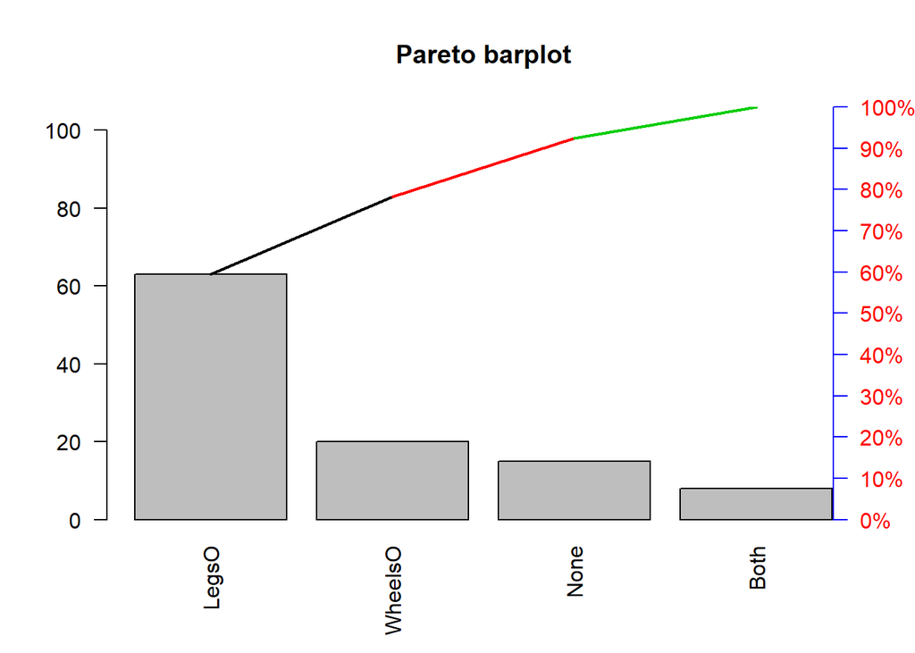

```r
pareto<-function(x,mn="Pareto barplot",...){  # x is a vector
  x.tab=table(x)
  xx.tab=sort(x.tab, decreasing=TRUE,index.return=FALSE)
  cumsum(as.vector(xx.tab))->cs
  length(x.tab)->lenx
  bp<-barplot(xx.tab,ylim=c(0,max(cs)),las=2)
  lb<-seq(0,cs[lenx],l=11)
  axis(side=4,at=lb,labels=paste(seq(0,100,length=11),"%",sep=""),las=1,line=-1,col="Blue",col.axis="Red")
  for(i in 1:(lenx-1)){
  segments(bp[i],cs[i],bp[i+1],cs[i+1],col=i,lwd=2)
  }
  title(main=mn,...)
}

pareto(l)
```

## 9. MS 2.4 - pg 27

### a. Construct a pie chart to describe the Microsoft products with security issues. Which product had the lowest proportion of security issues in 2012?

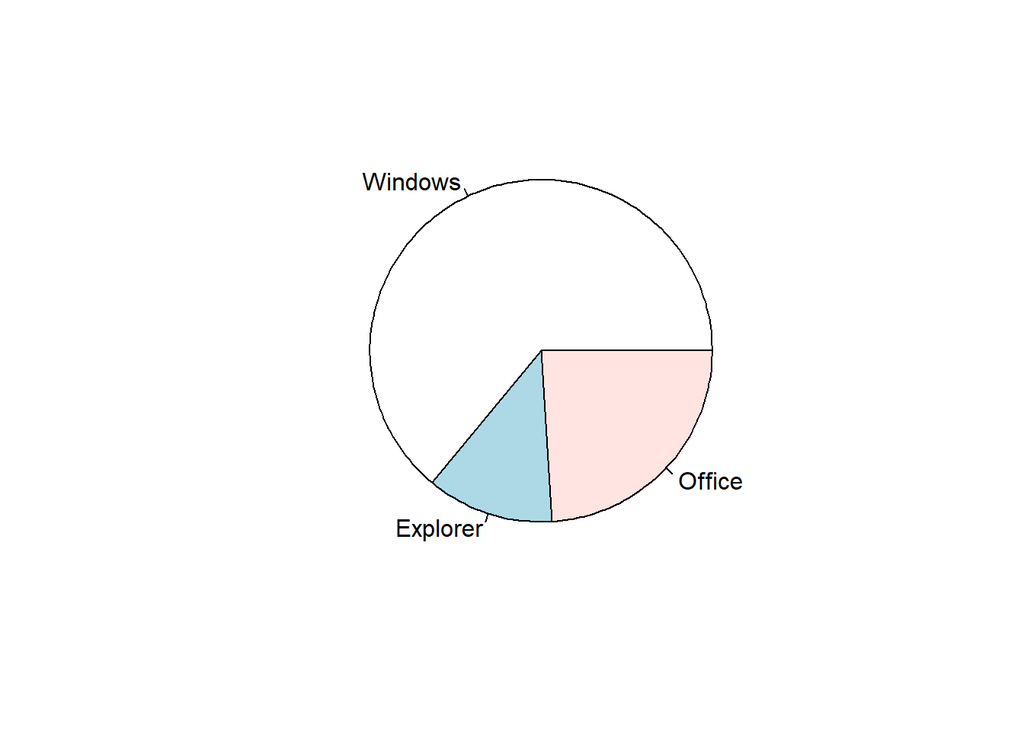

```r
freq=c(32,6,12)
RL=c("Windows","Explorer","Office")
ms=rep(RL,freq)
pie(freq,labels = RL)
```

> Exploer has the lowest proportion

### b. Construct a Pareto diagram to describe the expected repercussions from security issues. Based on the graph, what repercussion would you advise Microsoft to focus on?

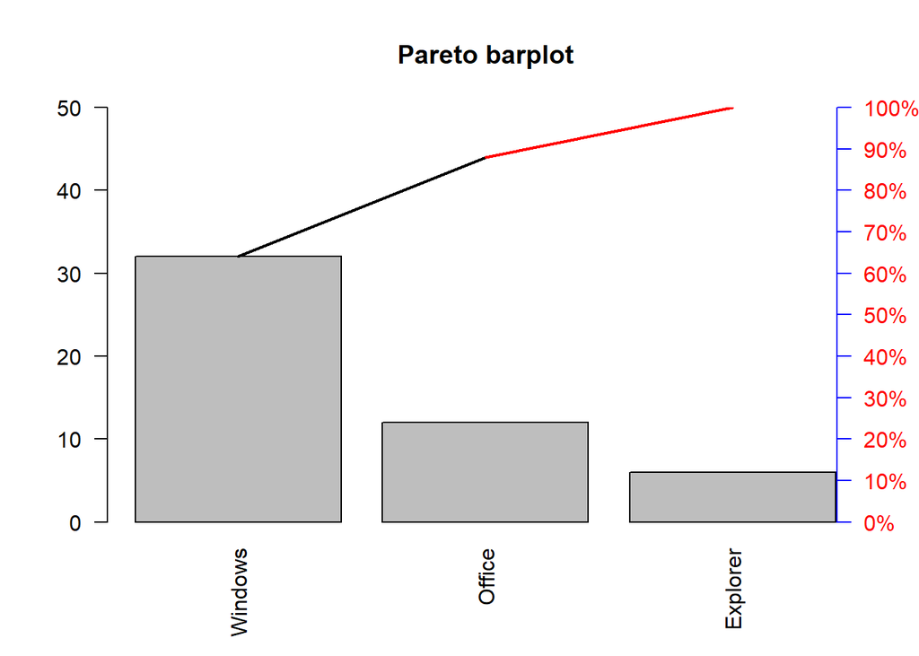

```r
pareto(ms)
```

> They should focus of fixing Windows